Skip to main content

# shell

A shell for running notebook code without a notebook server

```python
from fastcore.ansi import ansi2html
from IPython.display import HTML
from fastcore.test import *
from base64 import b64decode
from io import BytesIO
from PIL import Image
import tempfile
from contextlib import contextmanager
```

[source](https://github.com/AnswerDotAI/execnb/blob/main/execnb/shell.py#L53)

### ExecutionResult.__repr__

```python
def __repr__():
```

*Return repr(self).*

[source](https://github.com/AnswerDotAI/execnb/blob/main/execnb/shell.py#L50)

### ExecutionInfo.__repr__

```python
def __repr__():
```

*Return repr(self).*

[source](https://github.com/AnswerDotAI/execnb/blob/main/execnb/shell.py#L69)

### leading_comment_lines

```python
def leading_comment_lines(
    lines
):
```

*Input cleanup transform: drop leading blank/comment lines when the first code line is a cell magic, which IPython otherwise misparses as a line magic*

```python
s = InteractiveShell()
```

[source](https://github.com/AnswerDotAI/execnb/blob/main/execnb/shell.py#L75)

### CaptureShell

```python
def CaptureShell(
    path:str | pathlib.Path=None, mpl_format:str='retina', history:bool=False, timeout:Optional=None,
    profile:bool=False
):
```

*An enhanced, interactive shell for Python.*

Every [`CaptureShell`](https://AnswerDotAI.github.io/execnb/shell.html#captureshell) owns a private event loop, run forever by a daemon thread created at construction. All cell execution happens on that loop, through exactly one crossing point: `run` submits the coroutine with `run_coroutine_threadsafe` and blocks on the returned future. Nothing else ever touches the loop, so loop identity can’t be confused whatever context the caller is in – a sync CLI, an async server, or another kernel – and a `timeout` bounds the wait even when a cell blocks the loop in sync code. A timed-out or wedged shell may be unusable afterwards (its loop thread might still be inside the stuck cell): discard it and make a fresh one rather than reusing it.

Captured execution is factored into three pieces. `_captured` wraps a run with output capture and stdin blocking. `_run_res` packages the result and captured streams as the `AttrDict` that rendering uses. The run call itself comes in two forms sharing those pieces: `_run_async` awaits [`fastcore.nbio.run_cell`](https://fastcore.fast.ai/nbio.html#run_cell) and is what `run` submits to the shell’s loop, while sync `_run` goes through IPython’s own `run_cell` entry on the calling thread, for constructor-time setup lines.

[source](https://github.com/AnswerDotAI/execnb/blob/main/execnb/shell.py#L158)

### CaptureShell.load_profile

```python
def load_profile(
    name:str='default'
):
```

*Load profile `name`’s extensions and run its startup files (output suppressed), as `ipykernel` does*

`profile=True` makes a [`CaptureShell`](https://AnswerDotAI.github.io/execnb/shell.html#captureshell) behave like `ipykernel` at startup: it reads the IPython profile (honoring `IPYTHONDIR`), applies shell config traits from `ipython_config.py` and `ipython_kernel_config.py`, loads their `InteractiveShellApp.extensions`, and runs the profile’s `startup` files. (`exec_lines`/`exec_files` are not run.)

To demo profile loading we need a temporary IPython profile:

```python
@contextmanager
def _tmp_profile(cfg='', kcfg='', startup=''):
    with tempfile.TemporaryDirectory() as td, modified_env(IPYTHONDIR=td):
        pd = Path(td)/'profile_default'
        (pd/'startup').mkdir(parents=True)
        if cfg: (pd/'ipython_config.py').write_text(cfg)
        if kcfg: (pd/'ipython_kernel_config.py').write_text(kcfg)
        if startup: (pd/'startup'/'00-start.py').write_text(startup)
        yield td
```

Startup files in the profile’s `startup` directory are run, so their variables appear in the shell’s namespace:

```python
with _tmp_profile(startup="a=7\n"): test_eq(CaptureShell(profile=True).user_ns['a'], 7)
```

Extensions and startup files often print or display things as they load; `load_profile` suppresses that output so it can’t leak into test runs or captured results (failures still surface as warnings):

```python
with _tmp_profile(startup="b=1\nprint('starting up')\n"):
    with capture_output() as cap: sp = CaptureShell(profile=True)
test_eq((cap.stdout, sp.user_ns['b']), ('', 1))
```

Shell config traits from the profile’s config files are applied too:

```python
with _tmp_profile(kcfg="c.InteractiveShell.ast_node_interactivity='all'\n"):
    test_eq(CaptureShell(profile=True).ast_node_interactivity, 'all')
```

With the default `history=False`, the shell’s history database lives in memory, so creating shells never writes a `history.sqlite` into the profile directory:

```python
with _tmp_profile() as td:
    CaptureShell(profile=True)
    test_eq((Path(td)/'profile_default'/'history.sqlite').exists(), False)
```

### Cells / run

[source](https://github.com/AnswerDotAI/execnb/blob/main/execnb/shell.py#L175)

### format_exc

```python
def format_exc(
    e
):
```

*Format exception `e` as a string list*

[source](https://github.com/AnswerDotAI/execnb/blob/main/execnb/shell.py#L180)

### NbResult

```python
def NbResult(
    *args, **kwargs
):
```

*Built-in mutable sequence.*

If no argument is given, the constructor creates a new empty list. The argument must be an iterable if specified.

[source](https://github.com/AnswerDotAI/execnb/blob/main/execnb/shell.py#L218)

### CaptureShell.run

```python
def run(
    code:str, # Python/IPython code to run
    stdout:bool=True, # Capture stdout and save as output?
    stderr:bool=True, # Capture stderr and save as output?
    timeout:Optional=None, # Seconds before the run times out (None: `self.timeout`)
    verbose:bool=False, # Show stdout/stderr during execution
    grace:float=5, # Seconds to wait for cancellation after a timeout
):
```

*Run `code` on the shell’s loop, returning a list of all outputs in Jupyter notebook format*

Captured runs pass `store_history=True`, so IPython’s own trailing-`;` suppression applies, and the check is tokenizer-based: a comment after the `;` still suppresses. A cell magic’s payload is unaffected, since its transformed source ends in the `run_cell_magic(...)` call rather than a semicolon. That is the right behavior for payloads, which may be shell code, markup, or another language where a trailing `;` means nothing. A suppressed result is never populated, so no `execute_result` output appears. Streams are unaffected either way:

```python
cs = CaptureShell(mpl_format=None)
cs.register_magic_function(lambda line, cell: 'visible', 'cell', 'visible')
res = cs.run("%%visible\npayload;")
test_eq(res[0]['data']['text/plain'], ["'visible'"])
test_eq(cs.run("1+1;"), [])
test_eq(cs.run("print('kept'); 2;"), [dict(output_type='stream', name='stdout', text=['kept\n'])])
```

```python
s = CaptureShell()
```

```python
s.run("print(1)")
```

```
[{'name': 'stdout', 'output_type': 'stream', 'text': ['1\n']}]
```

Code can include magics and `!` shell commands:

```python
o = s.run("%time 1+1")
o
```

```
[{'name': 'stdout',
  'output_type': 'stream',
  'text': ['CPU times: user 1e+03 ns, sys: 0 ns, total: 1e+03 ns\n',
   'Wall time: 1.91 us\n']},
 {'data': {'text/plain': ['2']},
  'metadata': {},
  'output_type': 'execute_result',
  'execution_count': None}]
```

The result of the last successful execution is stored in `result`:

```python
s.result
```

```
2
```

A trailing `;` stops the result from being captured:

```python
s.run("1+2;")
```

```
[]
```

Code running inside a cell can itself call `run_cell` (the `%%capture` magic does exactly that). Such nested calls behave exactly as in plain IPython. They return an `ExecutionResult`, and their output flows to the enclosing capture context, so `%%capture` works:

```python
s.run("%%capture c\nprint(1)")
test_eq(s.user_ns['c'].stdout, '1\n')
s.run("r = get_ipython().run_cell('7')")
test_eq(s.user_ns['r'].__class__.__name__, 'ExecutionResult')
```

IPython requires a cell magic to be the very first line of a cell: even a comment above it makes the `%%foo` line parse as a *line* magic named `%foo`, which fails with a confusing “Line magic function `%%foo` not found” error. [`CaptureShell`](https://AnswerDotAI.github.io/execnb/shell.html#captureshell) smooths both edges: leading blank and comment lines above a cell magic are dropped (extending IPython’s own `leading_empty_lines` cleanup), and when real code precedes the magic (which can’t be auto-fixed), the error message explains the actual problem.

```python
s.run('# a narration comment\n\n%%capture c2\nprint(2)')
test_eq(s.exc, None)
test_eq(s.user_ns['c2'].stdout, '2\n')
```

```python
s.run('a=1\n%%capture c3\nprint(3)')
assert 'must start the cell' in str(s.exc)
```

```python
o = s.run("1/0")
o
```

```
[{'name': 'stdout',
  'output_type': 'stream',
  'text': ['\x1b[31m---------------------------------------------------------------------------\x1b[39m\n',
   '\x1b[31mZeroDivisionError\x1b[39m                         Traceback (most recent call last)\n',
   '\x1b[36mFile \x1b[39m\x1b[32m<ipython-input-1-9e1622b385b6>:1\x1b[39m\n',
   '\x1b[32m----> \x1b[39m\x1b[32m1\x1b[39m \x1b[30;43m1\x1b[39;49m\x1b[30;43m/\x1b[39;49m\x1b[30;43m0\x1b[39;49m\n',
   '\n',
   '\x1b[31mZeroDivisionError\x1b[39m: division by zero\n']},
 {'ename': 'ZeroDivisionError',
  'evalue': 'division by zero',
  'output_type': 'error',
  'traceback': ['Traceback (most recent call last):\n',
   '  File "/Users/jhoward/aai-ws/.venv/lib/python3.13/site-packages/IPython/core/interactiveshell.py", line 3748, in run_code\n    exec(code_obj, self.user_global_ns, self.user_ns)\n    ~~~~^^^^^^^^^^^^^^^^^^^^^^^^^^^^^^^^^^^^^^^^^^^^^\n',
   '  File "<ipython-input-1-9e1622b385b6>", line 1, in <module>\n    1/0\n    ~^~\n',
   'ZeroDivisionError: division by zero\n']}]
```

This is how IPython formats exceptions internally:

```python
from IPython.core.ultratb import VerboseTB
```

```python
with warnings.catch_warnings():
    warnings.filterwarnings("ignore", category=DeprecationWarning)
    formatter = VerboseTB(color_scheme='Linux')
```

```python
try: f()
except Exception as e:
    ex = e
    print(formatter.text(type(e), e, e.__traceback__))
```

```
---------------------------------------------------------------------------
NameError                                 Traceback (most recent call last)
Cell In[58], line 4
      1 try: f()
      2 except Exception as e:
      3     ex = e
----> 4     print(formatter.text(type(e), e, e.__traceback__))

NameError: name 'f' is not defined
```

```python
s.run("import time; time.sleep(0.1); print('no timeout')", timeout=1)
```

```
[{'name': 'stdout', 'output_type': 'stream', 'text': ['no timeout\n']}]
```

```python
o = s.run("import time; time.sleep(1.1)", timeout=1)
test_eq(o[0]['ename'], 'TimeoutError')
s.exc
```

[output not shown]

```python
o1 = s.run('from IPython.display import Markdown,display; print(0); print(1); display(Markdown("*2*")); Markdown("*1*")')
o1
```

```
[{'name': 'stdout', 'output_type': 'stream', 'text': ['0\n', '1\n']},
 {'data': {'text/plain': ['Markdown(*2*)'], 'text/markdown': ['*2*']},
  'metadata': {},
  'output_type': 'display_data'},
 {'data': {'text/plain': ['Markdown(*1*)'], 'text/markdown': ['*1*']},
  'metadata': {},
  'output_type': 'execute_result',
  'execution_count': None}]
```

```python
oaw = render_text(s.run("import asyncio\nawait asyncio.sleep(0.01)\n7"))
test_is('7' in oaw, True)
```

A captured run reports its exception structurally, packaged as an error output, so IPython’s own traceback print would be a colored duplicate in the captured stream. `showtraceback` therefore does nothing.

[source](https://github.com/AnswerDotAI/execnb/blob/main/execnb/shell.py#L247)

### CaptureShell.showsyntaxerror

```python
def showsyntaxerror(
    *args, **kwargs
):
```

*Like `showtraceback`*

[source](https://github.com/AnswerDotAI/execnb/blob/main/execnb/shell.py#L243)

### CaptureShell.showtraceback

```python
def showtraceback(
    *args, **kwargs
):
```

*A captured run reports its exception structurally; IPython’s printed traceback would be a colored duplicate in the stream*

```python
s = CaptureShell()
test_eq([x['output_type'] for x in s.run('1/0')], ['error'])
```

[source](https://github.com/AnswerDotAI/execnb/blob/main/execnb/shell.py#L254)

### render_outputs

```python
def render_outputs(
    outputs, ansi_renderer:function=_strip, include_imgs:bool=True, pygments:bool=False, md_tfm:function=noop,
    html_tfm:function=noop
):
```

*Call self as a function.*

```python
HTML(render_outputs(o))
```

```
---------------------------------------------------------------------------
TimeoutError                              Traceback (most recent call last)
Cell In[1], line 1
----> 1 import time; time.sleep(1.1)

File <ipython-input-1-289b30000b65>:7, in run_cell.<locals>.handler(*args)
      5 if not timeout: timeout = self.timeout
      6 if timeout:
----> 7     def handler(*args): raise TimeoutError()
      8     signal.signal(signal.SIGALRM, handler)
      9     signal.alarm(timeout)

TimeoutError:
```

We can use `ansi2html` to convert from ANSI to HTML for color rendering. You need some [css styles](https://github.com/fastai/fastcore/blob/master/examples/ansi.css) for the colors to render properly. Jupyter already has these built in so it’s not neccessary here, but if you plan on using this in another web app you will need to ensure that css styling is included.

```python
HTML(render_outputs(o, ansi2html))
```

```
---------------------------------------------------------------------------
TimeoutError                              Traceback (most recent call last)
Cell In[1], line 1
----> 1 import time; time.sleep(1.1)

File <ipython-input-1-289b30000b65>:7, in run_cell.<locals>.handler(*args)
      5 if not timeout: timeout = self.timeout
      6 if timeout:
----> 7     def handler(*args): raise TimeoutError()
      8     signal.signal(signal.SIGALRM, handler)
      9     signal.alarm(timeout)

TimeoutError:
```

Images and matplotlib figures are captured:

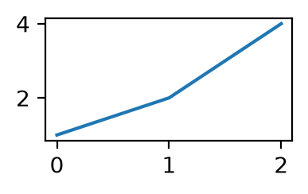

```python
res = s.run('''import matplotlib.pyplot as plt
plt.figure(figsize=(2,1))
plt.plot([1,2,4]);''')

HTML(render_outputs(res))
```

If an exception is raised then the exception type, object, and stacktrace are stored in `exc`:

```python
o = s.run('raise Exception("Oops")')
o
```

```
[{'name': 'stdout',
  'output_type': 'stream',
  'text': ['\x1b[31m---------------------------------------------------------------------------\x1b[39m\n',
   '\x1b[31mException\x1b[39m                                 Traceback (most recent call last)\n',
   '\x1b[36mCell\x1b[39m\x1b[36m \x1b[39m\x1b[32mIn[1]\x1b[39m\x1b[32m, line 1\x1b[39m\n',
   '\x1b[32m----> \x1b[39m\x1b[32m1\x1b[39m \x1b[38;5;28;01mraise\x1b[39;00m \x1b[38;5;167;01mException\x1b[39;00m(\x1b[33m"\x1b[39m\x1b[33mOops\x1b[39m\x1b[33m"\x1b[39m)\n',
   '\n',
   '\x1b[31mException\x1b[39m: Oops\n']},
 {'ename': 'Exception',
  'evalue': 'Oops',
  'output_type': 'error',
  'traceback': ['Traceback (most recent call last):\n',
   '  File "/Users/jhoward/aai-ws/.venv/lib/python3.13/site-packages/IPython/core/interactiveshell.py", line 3748, in run_code\n    exec(code_obj, self.user_global_ns, self.user_ns)\n    ~~~~^^^^^^^^^^^^^^^^^^^^^^^^^^^^^^^^^^^^^^^^^^^^^\n',
   '  File "<ipython-input-1-01648acb07bd>", line 1, in <module>\n    raise Exception("Oops")\n',
   'Exception: Oops\n']}]
```

```python
s.exc
```

```
Exception('Oops')
```

[source](https://github.com/AnswerDotAI/execnb/blob/main/execnb/shell.py#L287)

### CaptureShell.cell

```python
def cell(
    cell, stdout:bool=True, stderr:bool=True, verbose:bool=False, timeout:NoneType=None
):
```

*Run `cell`, skipping if not code, and store outputs (and the execution count) back in cell*

```python
clean = Path('../tests/clean.ipynb')
nb = read_nb(clean)
c = nb.cells[1]
c
```

```
{ 'cell_type': 'code',
  'execution_count': None,
  'id': 'b123d6d0',
  'idx_': 1,
  'metadata': {},
  'outputs': [],
  'source': 'print(1)\n2'}
```

```python
s.cell(c)
c.outputs
```

```
[{'name': 'stdout', 'output_type': 'stream', 'text': ['1\n']},
 {'data': {'text/plain': ['2']},
  'metadata': {},
  'output_type': 'execute_result',
  'execution_count': None}]
```

Re-running a cell that no longer produces output clears its stale outputs:

```python
c2 = read_nb(clean).cells[1]
s.cell(c2)
assert c2.outputs
c2.source = 'x = 1'
s.cell(c2)
test_eq(c2.outputs, [])
```

`cell` also records how long the run took, in the `metadata.execution` dict that Jupyter’s `record_timing` option uses: ISO 8601 timestamps under the standard message-key names, plus a `total` key holding elapsed seconds for programmatic use (`run_all`’s `postproc` receives the cell right after these are stamped). In an nbdev project `nbdev-clean` strips this metadata, so it stays out of committed notebooks unless allowed with `allowed_cell_metadata_keys`.

```python
timing = c.metadata.execution
assert 0 <= timing['total'] < 10
test_eq(set(timing), {'iopub.execute_input','shell.execute_reply','total'})
list(timing)
```

[output not shown]

[source](https://github.com/AnswerDotAI/execnb/blob/main/execnb/shell.py#L300)

### find_output

```python
def find_output(
    outp, # Output from `run`
    ot:str='execute_result', # Output_type to find
):
```

*Find first output of type `ot` in [`CaptureShell.run`](https://AnswerDotAI.github.io/execnb/shell.html#captureshell.run) output*

```python
find_output(c.outputs)['data']
```

```
{'text/plain': ['2']}
```

```python
find_output(c.outputs, 'stream')['text']
```

```
['1\n']
```

[source](https://github.com/AnswerDotAI/execnb/blob/main/execnb/shell.py#L308)

### out_exec

```python
def out_exec(
    outp
):
```

*Get data from execution result in `outp`.*

```python
out_exec(c.outputs)
```

```
'2'
```

[source](https://github.com/AnswerDotAI/execnb/blob/main/execnb/shell.py#L314)

### out_stream

```python
def out_stream(
    outp
):
```

*Get text from stream in `outp`.*

```python
out_stream(c.outputs)
```

```
'1'
```

[source](https://github.com/AnswerDotAI/execnb/blob/main/execnb/shell.py#L320)

### out_error

```python
def out_error(
    outp
):
```

*Get traceback from error in `outp`.*

### NBs

[source](https://github.com/AnswerDotAI/execnb/blob/main/execnb/shell.py#L344)

### CaptureShell.run_all

```python
def run_all(
    nb, # A notebook read with `nbclient` or `read_nb`
    exc_stop:bool=False, # Stop on exceptions?
    preproc:callable=_false, # Called before each cell is executed
    postproc:callable=_false, # Called after each cell is executed
    inject_code:str | None=None, # Code to inject into a cell
    inject_idx:int=0, # Cell to replace with `inject_code`
    verbose:bool=False, # Show stdout/stderr during execution
    cell_timeout:int=None, # Seconds before each cell times out (None: no limit)
    grace:float=5, # Seconds to wait for cancellation before giving up
):
```

*Run all cells in `nb`, stopping at first exception if `exc_stop`; tasks a run leaves behind are cancelled, with survivors in `self.leaks`*

```python
nb.cells[2].outputs
```

```
[]
```

```python
s.run_all(nb)
nb.cells[2].outputs
```

```
[{'data': {'text/plain': ['<IPython.core.display.Markdown object>'],
   'text/markdown': ["This is *bold*. Here's a [link](https://www.fast.ai)."]},
  'metadata': {},
  'output_type': 'execute_result',
  'execution_count': None}]
```

With `exc_stop=False` (the default), execution continues after exceptions, and exception details are stored into the appropriate cell’s output:

```python
nb.cells[-1].source
```

```
'raise Exception("Oopsie!")'
```

```python
nb.cells[-1].outputs
```

```
[{'name': 'stdout',
  'output_type': 'stream',
  'text': ['\x1b[31m---------------------------------------------------------------------------\x1b[39m\n',
   '\x1b[31mException\x1b[39m                                 Traceback (most recent call last)\n',
   '\x1b[36mCell\x1b[39m\x1b[36m \x1b[39m\x1b[32mIn[1]\x1b[39m\x1b[32m, line 1\x1b[39m\n',
   '\x1b[32m----> \x1b[39m\x1b[32m1\x1b[39m \x1b[38;5;28;01mraise\x1b[39;00m \x1b[38;5;167;01mException\x1b[39;00m(\x1b[33m"\x1b[39m\x1b[33mOopsie!\x1b[39m\x1b[33m"\x1b[39m)\n',
   '\n',
   '\x1b[31mException\x1b[39m: Oopsie!\n']},
 {'ename': 'Exception',
  'evalue': 'Oopsie!',
  'output_type': 'error',
  'traceback': ['Traceback (most recent call last):\n',
   '  File "/Users/jhoward/aai-ws/.venv/lib/python3.13/site-packages/IPython/core/interactiveshell.py", line 3748, in run_code\n    exec(code_obj, self.user_global_ns, self.user_ns)\n    ~~~~^^^^^^^^^^^^^^^^^^^^^^^^^^^^^^^^^^^^^^^^^^^^^\n',
   '  File "<ipython-input-1-1c97c1d317ab>", line 1, in <module>\n    raise Exception("Oopsie!")\n',
   'Exception: Oopsie!\n']}]
```

With `exc_stop=True`, exceptions in a cell are raised and no further processing occurs:

```python
try: s.run_all(nb, exc_stop=True)
except Exception as e: print(f"got exception: {e}")
```

```
got exception: Oopsie!
```

A hung cell can’t hang the caller: `cell_timeout` bounds each cell at the submission boundary, recording a `TimeoutError` (including the stacks of the loop’s pending tasks) as the cell’s output. When the run ends, tasks it started but never finished are cancelled, with any that refuse to die left in `leaks`:

```python
s2 = CaptureShell(mpl_format=None)
nb2 = new_nb([mk_cell('import asyncio'), mk_cell('t = asyncio.ensure_future(asyncio.sleep(60))'), mk_cell('await asyncio.sleep(60)')])
s2.run_all(nb2, cell_timeout=1, grace=1)
test_eq(nb2.cells[-1].outputs[0]['ename'], 'TimeoutError')
test_eq(s2.leaks, [])
test_eq(s2.user_ns['t'].cancelled(), True)
```

Cancellation needs the loop: a cell blocking in *sync* code pins the loop, so nothing can be delivered to it. The timeout still returns on schedule – the caller is never hung – but the shell’s thread stays stuck inside the cell, the stuck tasks land in `leaks`, and the shell should be discarded:

```python
s3 = CaptureShell(mpl_format=None)
nb3 = new_nb([mk_cell('import time'), mk_cell('time.sleep(4)')])
s3.run_all(nb3, cell_timeout=1, grace=0.2)
test_eq(nb3.cells[-1].outputs[0]['ename'], 'TimeoutError')
assert s3.leaks
```

We can pass a function to `preproc` to have it run on every cell. It can modify the cell as needed. If the function returns `True`, then that cell will not be executed. For instance, to skip the cell which raises an exception:

```python
nb = read_nb(clean)
s.run_all(nb, preproc=lambda c: 'raise' in c.source)
```

This cell will contain no output, since it was skipped.

```python
nb.cells[-1].outputs
```

```
[]
```

```python
nb.cells[1].outputs
```

```
[{'name': 'stdout', 'output_type': 'stream', 'text': ['1\n']},
 {'data': {'text/plain': ['2']},
  'metadata': {},
  'output_type': 'execute_result',
  'execution_count': None}]
```

You can also pass a function to `postproc` to modify a cell after it is executed.

[source](https://github.com/AnswerDotAI/execnb/blob/main/execnb/shell.py#L369)

### CaptureShell.execute

```python
def execute(
    src:str | pathlib.Path, # Notebook path to read from
    dest:str | None=None, # Notebook path to write to
    exc_stop:bool=False, # Stop on exceptions?
    preproc:callable=_false, # Called before each cell is executed
    postproc:callable=_false, # Called after each cell is executed
    inject_code:str | None=None, # Code to inject into a cell
    inject_path:str | pathlib.Path | None=None, # Path to file containing code to inject into a cell
    inject_idx:int=0, # Cell to replace with `inject_code`
    verbose:bool=False, # Show stdout/stderr during execution
    cell_timeout:int=None, # Seconds before each cell times out (None: no limit)
):
```

*Execute notebook from `src` and save with outputs to `dest*

This is a shortcut for the combination of `read_nb`, [`CaptureShell.run_all`](https://AnswerDotAI.github.io/execnb/shell.html#captureshell.run_all), and `write_nb`.

```python
s = CaptureShell()
try:
    s.execute(clean, 'tmp.ipynb')
    print(read_nb('tmp.ipynb').cells[1].outputs)
finally: Path('tmp.ipynb').unlink()
```

```
[{'name': 'stdout', 'output_type': 'stream', 'text': '1\n'}, {'data': {'text/plain': '2'}, 'execution_count': None, 'metadata': {}, 'output_type': 'execute_result'}]
```

```python
p = Path.home()/'git'/'fastcore'/'nbs'
n = p/'03a_parallel.ipynb'
```

[source](https://github.com/AnswerDotAI/execnb/blob/main/execnb/shell.py#L393)

### CaptureShell.prettytb

```python
def prettytb(
    fname:str | pathlib.Path=None, # filename to print alongside the traceback
):
```

*Show a pretty traceback for notebooks, optionally printing `fname`.*

If an error occurs while running a notebook, you can retrieve a pretty version of the error with the `prettytb` method:

```python
s = CaptureShell()
try: s.execute('../tests/error.ipynb', exc_stop=True)
except: print(s.prettytb())
```

```
AssertionError in ../tests/error.ipynb:
===========================================================================

While Executing Cell #2:
Traceback (most recent call last):
  File "<ipython-input-1-5c812627fe60>", line 2, in <module>
    try: s.execute('../tests/error.ipynb', exc_stop=True)
         ~~~~~~~~~^^^^^^^^^^^^^^^^^^^^^^^^^^^^^^^^^^^^^^^
  File "<ipython-input-1-4b062e10fd76>", line 19, in execute
    self.run_all(nb, exc_stop=exc_stop, preproc=preproc, postproc=postproc,
    ~~~~~~~~~~~~^^^^^^^^^^^^^^^^^^^^^^^^^^^^^^^^^^^^^^^^^^^^^^^^^^^^^^^^^^^
        inject_code=inject_code, inject_idx=inject_idx, verbose=verbose)
        ^^^^^^^^^^^^^^^^^^^^^^^^^^^^^^^^^^^^^^^^^^^^^^^^^^^^^^^^^^^^^^^^
  File "<ipython-input-1-54c4c86f5c38>", line 21, in run_all
    if self.exc and exc_stop: raise self.exc from None
                              ^^^^^^^^^^^^^^^^^^^^^^^^
  File "/Users/jhoward/aai-ws/.venv/lib/python3.13/site-packages/IPython/core/interactiveshell.py", line 3748, in run_code
    exec(code_obj, self.user_global_ns, self.user_ns)
    ~~~~^^^^^^^^^^^^^^^^^^^^^^^^^^^^^^^^^^^^^^^^^^^^^
  File "<ipython-input-1-b968a57a586e>", line 3, in <module>
    foo()
    ~~~^^
  File "/Users/jhoward/aai-ws/execnb/tests/err.py", line 2, in foo
    assert 13 == 98
           ^^^^^^^^
AssertionError
```

### render_text

Downstream kernels (e.g clikernel) print each executed cell’s outputs as plain text, so nbio’s `render_text` is re-exported here for them. Running notebook cells by id in the current kernel is aidialog’s `%nbrun` magic, built on [`fastcore.nbio.select_cells`](https://fastcore.fast.ai/nbio.html#select_cells) and [`fastcore.nbio.run_cell`](https://fastcore.fast.ai/nbio.html#run_cell).

`run_text` names the composition those kernels use: run code and return what a notebook’s output area would show, as concise text. One visible output renders bare (markdown-preferred), several arrive in `render_text`’s tagged form, and nothing visible is `''`.

[source](https://github.com/AnswerDotAI/execnb/blob/main/execnb/shell.py#L410)

### CaptureShell.run_text

```python
def run_text(
    code, stdout:bool=True, # Capture stdout and save as output?
    stderr:bool=True, # Capture stderr and save as output?
    timeout:Optional=None, # Seconds before the run times out (None: `self.timeout`)
    verbose:bool=False, # Show stdout/stderr during execution
    grace:float=5, # Seconds to wait for cancellation after a timeout
):
```

*Run `code`, returning its outputs rendered as concise text: what a notebook’s output area shows*

```python
s = CaptureShell()
o = s.run_text('print(1); 2')
test_is('1' in o and '2' in o, True)
test_eq(s.run_text('1;'), '')
test_eq(s.run_text("class M:\n    def _repr_markdown_(self): return '**hi**'\nM()"), '**hi**')
test_is('ZeroDivisionError' in s.run_text('1/0'), True)
o
```

[output not shown]

[`render_outputs`](https://AnswerDotAI.github.io/execnb/shell.html#render_outputs) is HTML-oriented. Downstream kernels print each executed cell’s result to stdout instead, so we use fastcore’s `render_text`, which renders outputs to concise text.

```python
def is_sublist(sub, lst): return any(lst[i:i+len(sub)] == sub for i in range(len(lst)-len(sub)+1))
```

```python
s2 = CaptureShell()
r = s2.run('from IPython.display import display,Markdown; display(Markdown("x"))')
test_eq(r[0]['output_type'], 'display_data')
r
```

[output not shown]

If you pass `inject_code` to [`CaptureShell.execute`](https://AnswerDotAI.github.io/execnb/shell.html#captureshell.execute) or [`CaptureShell.run_all`](https://AnswerDotAI.github.io/execnb/shell.html#captureshell.run_all), the source of `nb.cells[inject_idx]` will be replaced with `inject_code`. By default, the first cell is replaced. For instance consider this notebook:

```python
nb = read_nb('../tests/params.ipynb')
for c in nb.cells: print('- ',c.source)
```

```
-  a=1
-  print(a)
```

We can replace the first cell with `a=2` by passing that as `inject_code`, and the notebook will run with that change:

```python
nb = read_nb('../tests/params.ipynb')
s.run_all(nb, inject_code="a=2")
list(nb.cells)
```

```
[{'cell_type': 'code',
  'execution_count': None,
  'id': 'a63ce885',
  'metadata': {'time_run': '2026-01-04T20:52:46.502210+00:00'},
  'outputs': [],
  'source': 'a=2',
  'idx_': 0},
 {'cell_type': 'code',
  'execution_count': None,
  'id': 'ea528db5',
  'metadata': {'time_run': '2026-01-04T20:52:46.506607+00:00'},
  'outputs': [{'name': 'stdout', 'output_type': 'stream', 'text': ['2\n']}],
  'source': 'print(a)',
  'idx_': 1}]
```

This can be used with [`CaptureShell.execute`](https://AnswerDotAI.github.io/execnb/shell.html#captureshell.execute) to parameterise runs of models in notebooks. Place any defaults for configuration code needed in the first cell, and then when running `execute` pass in new parameters as needed in `inject_code`. To replace only some of the defaults, leave an empty cell as the second cell, and inject code using `inject_idx=1` to replace the empty second cell with code that overrides some of the defaults set in the first cell. When using `execute` you can pass `inject_path` instead of `inject_code` to read the injected code from a file.

[source](https://github.com/AnswerDotAI/execnb/blob/main/execnb/shell.py#L416)

### exec_nb

```python
def exec_nb(
    src:str, # Notebook path to read from
    dest:str='', # Notebook path to write to
    exc_stop:bool=False, # Stop on exceptions?
    inject_code:str=None, # Code to inject into a cell
    inject_path:str=None, # Path to file containing code to inject into a cell
    inject_idx:int=0, # Cell to replace with `inject_code`
    verbose:bool=False, # Show stdout/stderr during execution
    cell_timeout:int=None, # Seconds before each cell times out (None: no limit)
):
```

*Execute notebook from `src` and save with outputs to `dest`*

This is the command-line version of [`CaptureShell.execute`](https://AnswerDotAI.github.io/execnb/shell.html#captureshell.execute). Run `exec_nb -h` from the command line to see how to pass arguments. If you don’t pass `dest` then the output notebook won’t be saved; this is mainly useful for running tests.

[source](https://github.com/AnswerDotAI/execnb/blob/main/execnb/shell.py#L431)

### SmartCompleter

```python
def SmartCompleter(
    shell, # a pointer to the ipython shell itself.  This is needed
    # because this completer knows about magic functions, and those can
    # only be accessed via the ipython instance.
    namespace:NoneType=None, # an optional dict where completions are performed.
    jedi:bool=False
):
```

*Extension of the completer class with IPython-specific features*

```python
cc = SmartCompleter(get_ipython())

def test_set(a,b): return test_eq(set(a), set(b))

class _f:
    def __init__(self): self.bar,self.baz,self.room = 0,0,0

foo = _f()

assert set(cc("b")).issuperset(['bool', 'bytes'])
test_set(cc("foo.b"), ['bar', 'baz'])
test_set(cc("x=1; x = foo.b"), ['bar', 'baz'])
test_set(cc("ab"), ['abs'])
test_set(cc("b = ab"), ['abs'])
test_set(cc(""), [])
test_set(cc("foo."), ['bar', 'baz', 'room'])
test_set(cc("nonexistent.b"), [])
test_set(cc("foo.nonexistent.b"), [])
assert set(cc("import ab")).issuperset(['abc'])
test_set(cc("from abc import AB"), ['ABC', 'ABCMeta'])
```

```python
s = CaptureShell()
cc = SmartCompleter(s)
s.run('''def captures(pat, s, n, **kw):
    return 1''')
cc('captures(')
```

```
['n=', 'pat=', 's=']
```

[source](https://github.com/AnswerDotAI/execnb/blob/main/execnb/shell.py#L451)

### CaptureShell.complete

```python
def complete(
    c
): # The actual text that was completed.
```

*Return the completed text and a list of completions.*

```python
s = CaptureShell()
s.run('a=1')
s.complete('a.b')
```

```
['bit_count', 'bit_length']
```

```python
s.run('import re')
s.complete('re.compile(')
```

```
['flags=', 'pattern=']
```